# 고객 클러스터링

1. 조건 및 파라미터 설정

```python
dict_args = dict()
dict_args['cluster_count'] = list(range(2, 11))
dict_args['base_file'] = 'OnlineRetail.csv'
dict_args['min_cluster_size'] = 30
```

```python
dict_args
```

```
{'cluster_count': [2, 3, 4, 5, 6, 7, 8, 9, 10],
 'base_file': 'OnlineRetail.csv',
 'min_cluster_size': 30}
```

2. 샘플용 데이터 로딩

```python
import pandas as pd
df = pd.read_csv(dict_args['base_file'], encoding = 'cp1252')
display(df)
```

|  | InvoiceNo | StockCode | Description | Quantity | InvoiceDate | UnitPrice | CustomerID | Country |
| --- | --- | --- | --- | --- | --- | --- | --- | --- |
| 0 | 536365 | 85123A | WHITE HANGING HEART T-LIGHT HOLDER | 6 | 01-12-2010 08:26 | 2.55 | 17850.0 | United Kingdom |
| 1 | 536365 | 71053 | WHITE METAL LANTERN | 6 | 01-12-2010 08:26 | 3.39 | 17850.0 | United Kingdom |
| 2 | 536365 | 84406B | CREAM CUPID HEARTS COAT HANGER | 8 | 01-12-2010 08:26 | 2.75 | 17850.0 | United Kingdom |
| 3 | 536365 | 84029G | KNITTED UNION FLAG HOT WATER BOTTLE | 6 | 01-12-2010 08:26 | 3.39 | 17850.0 | United Kingdom |
| 4 | 536365 | 84029E | RED WOOLLY HOTTIE WHITE HEART. | 6 | 01-12-2010 08:26 | 3.39 | 17850.0 | United Kingdom |
| ... | ... | ... | ... | ... | ... | ... | ... | ... |
| 541904 | 581587 | 22613 | PACK OF 20 SPACEBOY NAPKINS | 12 | 09-12-2011 12:50 | 0.85 | 12680.0 | France |
| 541905 | 581587 | 22899 | CHILDREN'S APRON DOLLY GIRL | 6 | 09-12-2011 12:50 | 2.10 | 12680.0 | France |
| 541906 | 581587 | 23254 | CHILDRENS CUTLERY DOLLY GIRL | 4 | 09-12-2011 12:50 | 4.15 | 12680.0 | France |
| 541907 | 581587 | 23255 | CHILDRENS CUTLERY CIRCUS PARADE | 4 | 09-12-2011 12:50 | 4.15 | 12680.0 | France |
| 541908 | 581587 | 22138 | BAKING SET 9 PIECE RETROSPOT | 3 | 09-12-2011 12:50 | 4.95 | 12680.0 | France |

541909 rows × 8 columns

```python
df.info()
```

```
<class 'pandas.core.frame.DataFrame'>
RangeIndex: 541909 entries, 0 to 541908
Data columns (total 8 columns):
 #   Column       Non-Null Count   Dtype
---  ------       --------------   -----
 0   InvoiceNo    541909 non-null  object
 1   StockCode    541909 non-null  object
 2   Description  540455 non-null  object
 3   Quantity     541909 non-null  int64
 4   InvoiceDate  541909 non-null  object
 5   UnitPrice    541909 non-null  float64
 6   CustomerID   406829 non-null  float64
 7   Country      541909 non-null  object
dtypes: float64(2), int64(1), object(5)
memory usage: 33.1+ MB
```

3. 데이터 전처리

```python
df_source = df.copy()
df_source['CustomerID'] = df_source['CustomerID'].fillna(-1)
df_source['CustomerID'] = df_source['CustomerID'].astype(float)
df_source['CustomerID'] = df_source['CustomerID'].astype(int)
df_source['CustomerID'] = df_source['CustomerID'].astype(str)

df_source['Amount'] = df_source['UnitPrice'] * df_source['Quantity']

df_source['InvoiceDate'] = pd.to_datetime(df_source['InvoiceDate'], format = '%d-%m-%Y %H:%M')
```

```python
df_source.head()
```

|  | InvoiceNo | StockCode | Description | Quantity | InvoiceDate | UnitPrice | CustomerID | Country | Amount |
| --- | --- | --- | --- | --- | --- | --- | --- | --- | --- |
| 0 | 536365 | 85123A | WHITE HANGING HEART T-LIGHT HOLDER | 6 | 2010-12-01 08:26:00 | 2.55 | 17850 | United Kingdom | 15.30 |
| 1 | 536365 | 71053 | WHITE METAL LANTERN | 6 | 2010-12-01 08:26:00 | 3.39 | 17850 | United Kingdom | 20.34 |
| 2 | 536365 | 84406B | CREAM CUPID HEARTS COAT HANGER | 8 | 2010-12-01 08:26:00 | 2.75 | 17850 | United Kingdom | 22.00 |
| 3 | 536365 | 84029G | KNITTED UNION FLAG HOT WATER BOTTLE | 6 | 2010-12-01 08:26:00 | 3.39 | 17850 | United Kingdom | 20.34 |
| 4 | 536365 | 84029E | RED WOOLLY HOTTIE WHITE HEART. | 6 | 2010-12-01 08:26:00 | 3.39 | 17850 | United Kingdom | 20.34 |

고객 클러스터링을 해야하는데 마땅한 수치형 변수가 Quantity UnitPrice 곱한 파생변수 Amount랑 Quantity, UnitPrice 밖에 없음..

R, F, M 기준의 수치형 변수를 생성

```python
import numpy as np
# Recency
df_max = np.max(df_source['InvoiceDate'])
df_source['diff'] = df_max - df_source['InvoiceDate']
df_diffs = df_source.groupby(['CustomerID']).agg(Recency = ('diff', np.min))
df_diffs['Recency'] = df_diffs['Recency'].dt.days

# Frequency
df_frequency = df_source.groupby(['CustomerID']).agg(Frequency = ('InvoiceNo', 'count'))

# Monetary
df_amount = df_source.groupby(['CustomerID']).agg(Amount = ('Amount', sum))

df_final = df_diffs.join(df_frequency, how = 'inner')
df_final = df_final.join(df_amount, how = 'inner')
df_final = df_final.fillna(-1)

df_final = df_final[df_final.index != '-1']
df_final.head()
```

| CustomerID | Recency | Frequency | Amount |
| --- | --- | --- | --- |
| 12346 | 325 | 2 | 0.00 |
| 12347 | 1 | 182 | 4310.00 |
| 12348 | 74 | 31 | 1797.24 |
| 12349 | 18 | 73 | 1757.55 |
| 12350 | 309 | 17 | 334.40 |

RFM 방식으로 산출한 고객 클러스터링 실행

```python
#to scale the data using z-score
from sklearn.preprocessing import StandardScaler

# importing clustering algorithms
from sklearn.cluster import KMeans
from sklearn.mixture import GaussianMixture

# Silhouette score
from sklearn.metrics import silhouette_score


df_base_cluster_source = df_final.copy()

# 데이터 스케일링
scaler = StandardScaler()
data_scaled = pd.DataFrame(scaler.fit_transform(df_base_cluster_source), columns = df_base_cluster_source.columns)
data_scaled.head()
```

|  | Recency | Frequency | Amount |
| --- | --- | --- | --- |
| 0 | 2.322023 | -0.391720 | -0.231001 |
| 1 | -0.893733 | 0.382657 | 0.293432 |
| 2 | -0.169196 | -0.266959 | -0.012316 |
| 3 | -0.725005 | -0.086271 | -0.017146 |
| 4 | 2.163220 | -0.327188 | -0.190312 |

```python
data_scaled_copy = data_scaled.copy(deep = True)
```

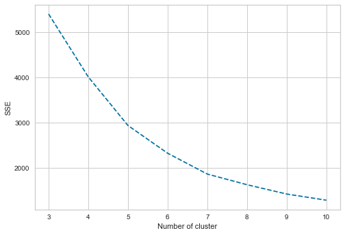

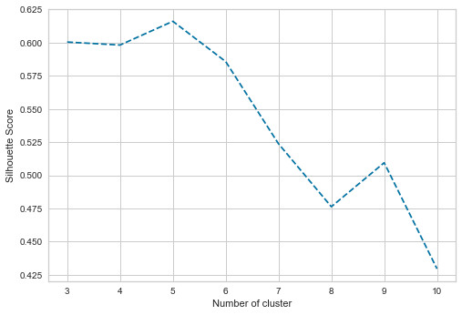

```python
import matplotlib.pyplot as plt

sse = {} # 클러스터 중심과 클러스터샘플간 거리제곱합 (이너셔)
sc = {} # 실루엣 계수

for k in dict_args['cluster_count']:
    if k == 2:
        continue
    kmeans = KMeans(n_clusters = k, random_state = 1, init = 'k-means++')
    kmeans.fit(data_scaled)
    sse[k] = kmeans.inertia_

    labels = kmeans.predict(data_scaled)
    sc[k] = silhouette_score(data_scaled, labels)

# Elbow plot
plt.figure()
plt.plot(list(sse.keys()), list(sse.values()), 'bx--')
plt.xlabel("Number of cluster")
plt.ylabel("SSE")
plt.show()

# Elbow point
plt.figure()
plt.plot(list(sc.keys()), list(sc.values()), 'bx--')
plt.xlabel("Number of cluster")
plt.ylabel("Silhouette Score")
plt.show()
```

k = 5 에서 실루엣 계수가 가장 높은것을 확인할 수 있음

https://scikit-learn.org/stable/auto_examples/cluster/plot_kmeans_silhouette_analysis.html

```python
def visualize_silouette(cluster_lists, X_features):
    from sklearn.cluster import KMeans
    from sklearn.metrics import silhouette_samples, silhouette_score

    import matplotlib.pyplot as plt
    import matplotlib.cm as cm
    import math

    n_cols = len(cluster_lists)
    fig, axs = plt.subplots(figsize = (4*n_cols, 4), nrows = 1, ncols = n_cols)

    for ind, n_cluster in enumerate(cluster_lists):

        clusterer = KMeans(n_clusters = n_cluster, max_iter = 500, random_state = 1, init = 'k-means++')
        cluster_labels = clusterer.fit_predict(X_features)

        sil_avg = silhouette_score(X_features, cluster_labels)
        sil_values = silhouette_samples(X_features, cluster_labels)

        y_lower = 10
        axs[ind].set_title("Number of Cluster : "+ str(n_cluster) + '\n Silhouette Score :' + str(round(sil_avg,3)) )
        axs[ind].set_xlabel("The silhouette coefficient values")
        axs[ind].set_ylabel("Cluster label")
        axs[ind].set_xlim([-0.1, 1])
        axs[ind].set_ylim([0, len(X_features) + (n_cluster + 1) * 10])
        axs[ind].set_yticks([])
        axs[ind].set_xticks([0, 0.2, 0.4, 0.6, 0.8, 1])

        for i in range(n_cluster):
            ith_cluster_sil_values = sil_values[cluster_labels == i]
            ith_cluster_sil_values.sort()

            size_cluster_i = ith_cluster_sil_values.shape[0]
            y_upper = y_lower + size_cluster_i

            color = cm.nipy_spectral(float(i) / n_cluster)
            axs[ind].fill_betweenx(np.arange(y_lower, y_upper), 0, ith_cluster_sil_values, \
                                facecolor=color, edgecolor=color, alpha=0.7)
            axs[ind].text(-0.05, y_lower + 0.5 * size_cluster_i, str(i))
            y_lower = y_upper + 10

        axs[ind].axvline(x=sil_avg, color="red", linestyle="--")
```

```python
dict_args['cluster_count']
```

```
[2, 3, 4, 5, 6, 7, 8, 9, 10]
```

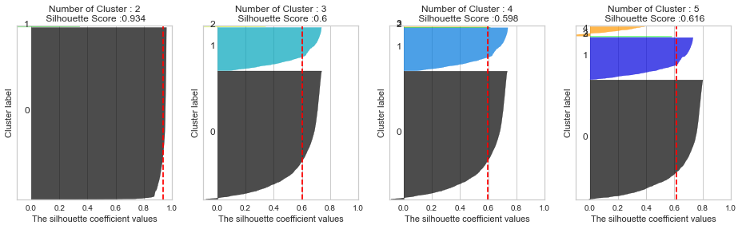

```python
visualize_silouette(dict_args['cluster_count'][:4], data_scaled)
```

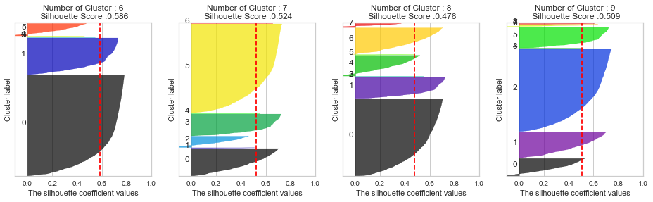

```python
visualize_silouette(dict_args['cluster_count'][4:8], data_scaled)
```

- 빨간색 점선 : 전체 데이터의 실루엣 계수 평균임.

```python
def visualize_silouette(cluster_lists, X_features):
    from sklearn.cluster import KMeans
    from sklearn.metrics import silhouette_samples, silhouette_score

    # importing PCA
    from sklearn.decomposition import PCA

    import matplotlib.pyplot as plt
    import matplotlib.cm as cm
    import math


    fig, (ax1, ax2) = plt.subplots(nrows = 1, ncols = 2)

    for n_cluster in cluster_lists:

        clusterer = KMeans(n_clusters = n_cluster, max_iter = 500, random_state = 1, init = 'k-means++')
        cluster_labels = clusterer.fit_predict(X_features)

        sil_avg = silhouette_score(X_features, cluster_labels)
        sil_values = silhouette_samples(X_features, cluster_labels)

        y_lower = 10
        ax1.set_title("Number of Cluster : "+ str(n_cluster) + '\n Silhouette Score :' + str(round(sil_avg,3)) )
        ax1.set_xlabel("The silhouette coefficient values")
        ax1.set_ylabel("Cluster label")
        ax1.set_xlim([-0.1, 1])
        ax1.set_ylim([0, len(X_features) + (n_cluster + 1) * 10])
        ax1.set_yticks([])
        ax1.set_xticks([0, 0.2, 0.4, 0.6, 0.8, 1])

        for i in range(n_cluster):
            ith_cluster_sil_values = sil_values[cluster_labels == i]
            ith_cluster_sil_values.sort()

            size_cluster_i = ith_cluster_sil_values.shape[0]
            y_upper = y_lower + size_cluster_i

            color = cm.nipy_spectral(float(i) / n_cluster)
            ax1.fill_betweenx(np.arange(y_lower, y_upper), 0, ith_cluster_sil_values, \
                                facecolor=color, edgecolor=color, alpha=0.7)
            ax1.text(-0.05, y_lower + 0.5 * size_cluster_i, str(i))
            y_lower = y_upper + 10

        ax1.axvline(x=sil_avg, color="red", linestyle="--")


    # 2nd Plot showing the actual clusters formed

    # get PC1, PC2 from PCA
    pca = PCA(n_components = 2, random_state = 1)
    data_pca = pd.DataFrame(pca.fit_transform(X_features), columns = ['PC1', 'PC2']).to_numpy()

    colors = cm.nipy_spectral(cluster_labels.astype(float) / n_cluster)
    ax2.scatter(data_pca[:, 0], data_pca[:, 1], marker='.', s=30, lw=0, alpha=0.7,
                c=colors, edgecolor='k')


   # Labeling the clusters
    centers = clusterer.cluster_centers_
    # Draw white circles at cluster centers
    ax2.scatter(centers[:, 0], centers[:, 1], marker='o',
                c="white", alpha=1, s=200, edgecolor='k')

    for i, c in enumerate(centers):
        ax2.scatter(c[0], c[1], marker='$%d$' % i, alpha=1,
                    s=50, edgecolor='k')

    ax2.set_title("The visualization of the clustered data.")
    ax2.set_xlabel("Feature space for the 1st feature")
    ax2.set_ylabel("Feature space for the 2nd feature")

    plt.suptitle(("Silhouette analysis for KMeans clustering on sample data "
                  "with n_clusters = %d" % n_cluster),
                 fontsize=14, fontweight='bold')
```

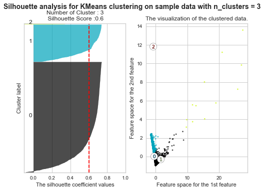

```python
visualize_silouette([3], data_scaled)
```

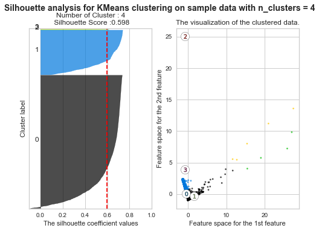

```python
visualize_silouette([4], data_scaled)
```

군집 3으로 하여 0, 1, 2 로 나누는 것이 잘 나누어진 집단으로 보임